# Making Graphs with R

ITAO 20200: Foundations of Statistics

J. S. Akosa, F. Bilson Darku, J. Waddell, & M. O’Callaghan

## Bank Salaries Data Set

This bank employee dataset contains information on individual employees. Each row represents one employee, with variables capturing demographics, job roles, and experience. The dataset includes gender information, education level (EducLev), and whether the job is IT-related (IT_Job). It also includes the employee’s JobGrade, ranging from 1 (lowest) to 6 (highest), as well as their years of experience at the current bank (YrsExper), years of experience at another bank (YrsPrior), and age.

To read in the data set, the following command line is used:

```r
bank <- read.csv("https://www.crc.nd.edu/~jakosa/ITAO_20200/Data/SalaryData.csv")
```

We will use education level (EducLev) throughout this guide. Education level is an ordinal variable, and displays using this variable should reflect this natural ordering. However, since the default in R is to display categories in alphabetical order, we need to change the ordering so that it reflects what we expect to see from increasing amounts of education.

The `factor` command will create a custom arrangement of category labels.

```r
bank$EducLev <- factor(bank$EducLev, levels = c("HS Diploma", "Some College",
                                                "College Degree", "Some Grad",
                                                "Grad Degree"))
```

## Simple Descriptive Plots in R

Visual aids are sometimes useful for conveying information to consumers. There are several simple plot commands in the basic R package. A much more sophisticated way of producing plots is with ggplot, which is part of the **dplyr** (pronounced “Dee-plyer,” like you are picking up a pair of pliers) package. These techniques are beyond the scope of our needs in this course, but they can be learned in more advanced courses in Business Analytics.

## Bar Chart

We can visualize categorical frequency data with a *bar chart*. The categories are listed along the x-axis, and the frequency counts are represented by the height of the bars. Since this is a bar chart, the bars do not touch.

The visualization is enhanced with x- and y-axis labels. Each command is explained with a comment below. Note that the `col` command merely changes the color of the bars when used in this context.

Due to printing constraints, it may look like some category labels have been omitted. This is normal. If you zoom in on the Plots pane in RStudio, you will see that all category labels are there.

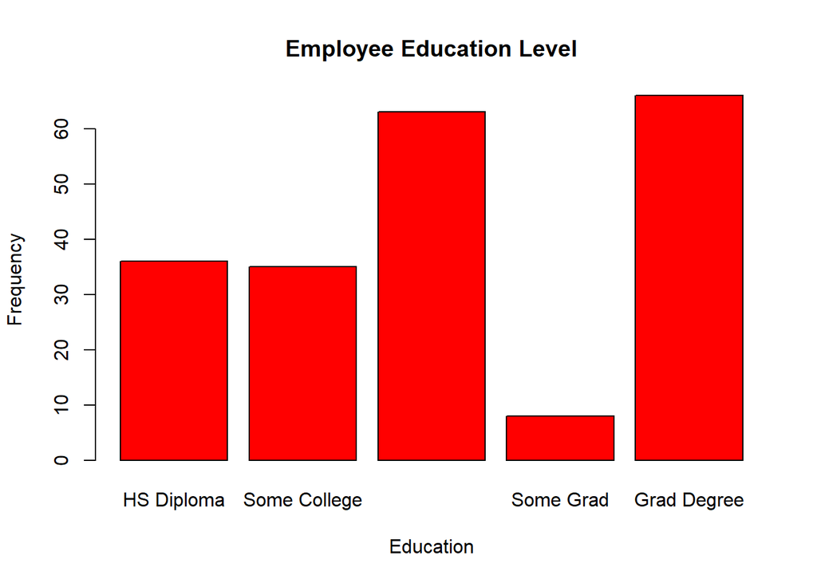

```r
# Create with the `barplot` command.
# `counts` is the name of the variable being plotted, created from a table of frequencies on this variable.
# `main` command gives the chart a title.
# `xlab` provides a label for the x-axis.
# `ylab` provides a label for the y-axis.
# `col` gives the bars a color; there are many predefined color words in R.
counts<- table(bank$EducLev)
barplot(counts,
        main = "Employee Education Level",
        xlab = "Education",
        ylab = "Frequency",
        col="red")
```

The following makes a horizontal bar graph (notice the use of horiz = TRUE) and changes the color of the bars.

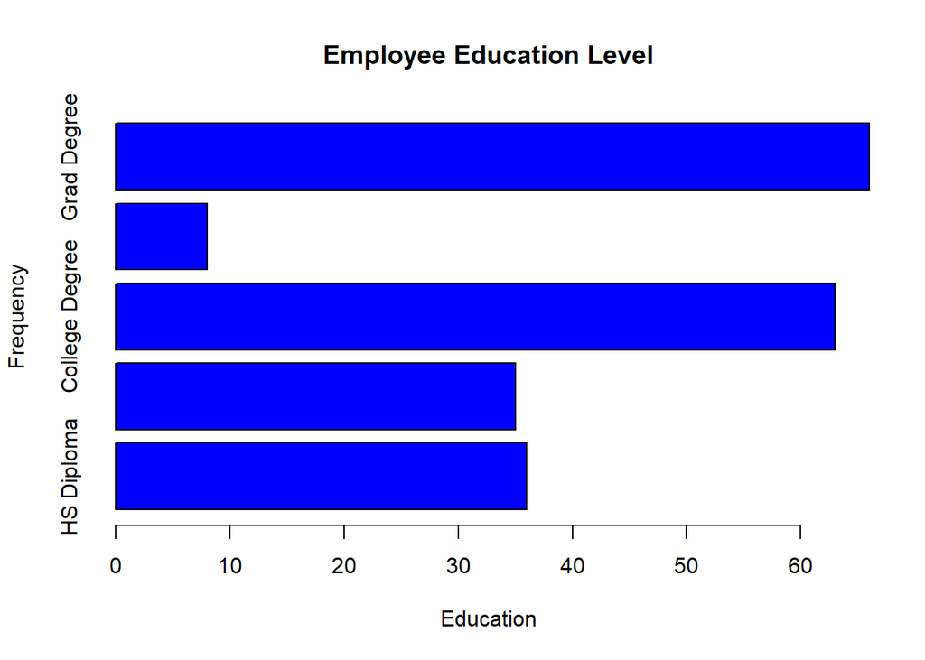

```r
barplot(counts,
        main = "Employee Education Level",
        xlab = "Education",
        ylab = "Frequency",
        col = "blue",
        horiz = TRUE)
```

## Pareto Chart

A *Pareto chart* is a type of bar graph that shows categories of data in order from most frequent to least frequent, often combined with a line graph that shows the cumulative percentage. It helps highlight which factors are the most important or have the biggest impact.

To create a Pareto chart, the **qcc** package must be installed. Use the Packages tab in the lower right hand corner panel of the RStudio screen to install this package, or run this command line.

```r
install.packages("qcc")
```

Package installation *only needs to happen one time per machine.* However, if a function or command from a package is to be used in an R session, then the `library` function must be run. The library command needs to be run only once per R session, and it has to be run prior to any command lines involving functions from that package.

To create a Pareto chart for our education level variable:

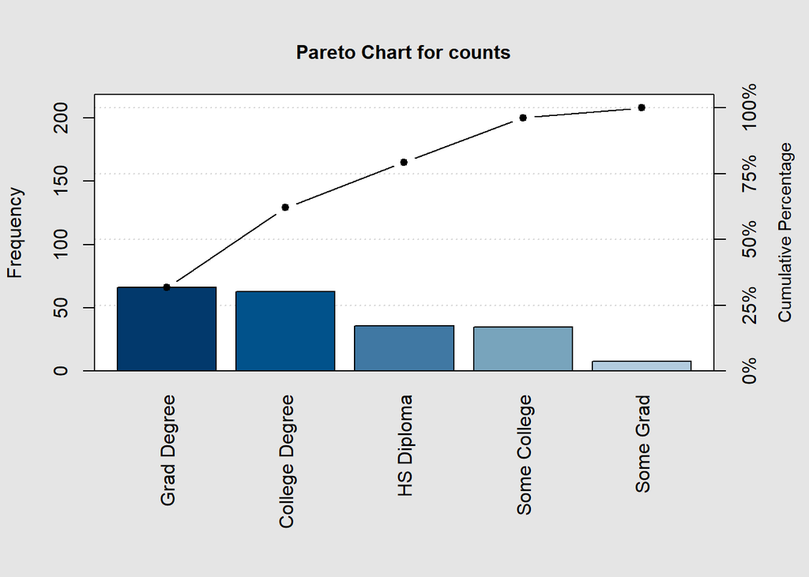

```
##
## Pareto chart analysis for counts
##                  Frequency Cum.Freq. Percentage Cum.Percent.
##   Grad Degree       66.000    66.000     31.731       31.731
##   College Degree    63.000   129.000     30.288       62.019
##   HS Diploma        36.000   165.000     17.308       79.327
##   Some College      35.000   200.000     16.827       96.154
##   Some Grad          8.000   208.000      3.846      100.000
```

```r
library(qcc)
pareto.chart(counts)
```

## Histogram

A histogram is a type of graph that shows how data are distributed by grouping values into intervals (called bins) and displaying the frequency of data in each bin as bars. It’s useful for seeing the shape, spread, and center of a dataset.

Since rolling from one interval to another is continuous, a histogram is used with quantitative data. The response categories are ordered from lowest to highest.

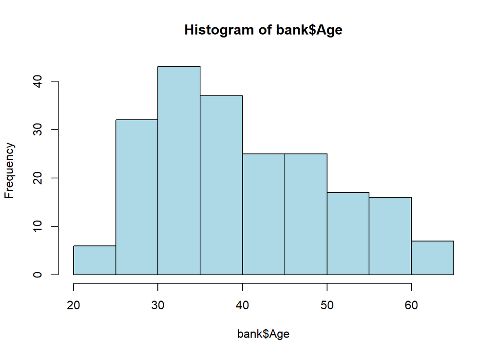

```r
hist(bank$Age,
     col = "lightblue")
```